# Risk Factor Analysis

## Outcome Variable

**Outcome Variable:** y_rate_wtkg

## Predictor Variables

**Intervention Variable:** nchldlt5

**Adjustment Set:**

- arm
- W_mage
- meducyrs
- feducyrs
- hhwealth_quart
- hfoodsec
- W_mhtcm
- W_mwtkg
- W_mbmi
- W_nrooms
- W_parity
- impfloor
- impsan
- safeh20
- delta_W_mage
- delta_meducyrs
- delta_feducyrs
- delta_hhwealth_quart
- delta_hfoodsec
- delta_W_mhtcm
- delta_W_mwtkg
- delta_W_mbmi
- delta_W_nrooms
- delta_W_parity
- delta_impfloor
- delta_impsan
- delta_safeh20

## Stratifying Variables

The analysis was stratified on these variable(s):

- agecat
- studyid
- country

## Data Summary

| agecat | studyid | country | nchldlt5 | n_cell | n | outcome_variable |
| --- | --- | --- | --- | --- | --- | --- |
| 0-3 months | ki1000108-IRC | INDIA | 1 | 87 | 394 | y_rate_wtkg |
| 0-3 months | ki1000108-IRC | INDIA | 2+ | 307 | 394 | y_rate_wtkg |
| 0-3 months | ki1017093b-PROVIDE | BANGLADESH | 1 | 471 | 640 | y_rate_wtkg |
| 0-3 months | ki1017093b-PROVIDE | BANGLADESH | 2+ | 169 | 640 | y_rate_wtkg |
| 0-3 months | ki1017093c-NIH-Crypto | BANGLADESH | 1 | 516 | 725 | y_rate_wtkg |
| 0-3 months | ki1017093c-NIH-Crypto | BANGLADESH | 2+ | 209 | 725 | y_rate_wtkg |
| 0-3 months | ki1066203-TanzaniaChild2 | TANZANIA, UNITED REPUBLIC OF | 1 | 1380 | 2014 | y_rate_wtkg |
| 0-3 months | ki1066203-TanzaniaChild2 | TANZANIA, UNITED REPUBLIC OF | 2+ | 634 | 2014 | y_rate_wtkg |
| 0-3 months | kiGH5241-JiVitA-3 | BANGLADESH | 1 | 12683 | 20270 | y_rate_wtkg |
| 0-3 months | kiGH5241-JiVitA-3 | BANGLADESH | 2+ | 7587 | 20270 | y_rate_wtkg |
| 3-6 months | ki1000108-IRC | INDIA | 1 | 87 | 399 | y_rate_wtkg |
| 3-6 months | ki1000108-IRC | INDIA | 2+ | 312 | 399 | y_rate_wtkg |
| 3-6 months | ki1017093b-PROVIDE | BANGLADESH | 1 | 437 | 601 | y_rate_wtkg |
| 3-6 months | ki1017093b-PROVIDE | BANGLADESH | 2+ | 164 | 601 | y_rate_wtkg |
| 3-6 months | ki1017093c-NIH-Crypto | BANGLADESH | 1 | 498 | 702 | y_rate_wtkg |
| 3-6 months | ki1017093c-NIH-Crypto | BANGLADESH | 2+ | 204 | 702 | y_rate_wtkg |
| 3-6 months | ki1066203-TanzaniaChild2 | TANZANIA, UNITED REPUBLIC OF | 1 | 1151 | 1659 | y_rate_wtkg |
| 3-6 months | ki1066203-TanzaniaChild2 | TANZANIA, UNITED REPUBLIC OF | 2+ | 508 | 1659 | y_rate_wtkg |
| 3-6 months | kiGH5241-JiVitA-3 | BANGLADESH | 1 | 8194 | 12711 | y_rate_wtkg |
| 3-6 months | kiGH5241-JiVitA-3 | BANGLADESH | 2+ | 4517 | 12711 | y_rate_wtkg |
| 6-9 months | ki1000108-IRC | INDIA | 1 | 89 | 410 | y_rate_wtkg |
| 6-9 months | ki1000108-IRC | INDIA | 2+ | 321 | 410 | y_rate_wtkg |
| 6-9 months | ki1017093b-PROVIDE | BANGLADESH | 1 | 417 | 576 | y_rate_wtkg |
| 6-9 months | ki1017093b-PROVIDE | BANGLADESH | 2+ | 159 | 576 | y_rate_wtkg |
| 6-9 months | ki1017093c-NIH-Crypto | BANGLADESH | 1 | 491 | 693 | y_rate_wtkg |
| 6-9 months | ki1017093c-NIH-Crypto | BANGLADESH | 2+ | 202 | 693 | y_rate_wtkg |
| 6-9 months | ki1066203-TanzaniaChild2 | TANZANIA, UNITED REPUBLIC OF | 1 | 1040 | 1488 | y_rate_wtkg |
| 6-9 months | ki1066203-TanzaniaChild2 | TANZANIA, UNITED REPUBLIC OF | 2+ | 448 | 1488 | y_rate_wtkg |
| 6-9 months | ki1148112-LCNI-5 | MALAWI | 1 | 260 | 554 | y_rate_wtkg |
| 6-9 months | ki1148112-LCNI-5 | MALAWI | 2+ | 294 | 554 | y_rate_wtkg |

[output cut: 54 more lines]

The following strata were considered:

- agecat: 0-3 months, studyid: ki1000108-IRC, country: INDIA
- agecat: 0-3 months, studyid: ki1017093b-PROVIDE, country: BANGLADESH
- agecat: 0-3 months, studyid: ki1017093c-NIH-Crypto, country: BANGLADESH
- agecat: 0-3 months, studyid: ki1066203-TanzaniaChild2, country: TANZANIA, UNITED REPUBLIC OF
- agecat: 0-3 months, studyid: kiGH5241-JiVitA-3, country: BANGLADESH
- agecat: 12-15 months, studyid: ki1000108-IRC, country: INDIA
- agecat: 12-15 months, studyid: ki1017093b-PROVIDE, country: BANGLADESH
- agecat: 12-15 months, studyid: ki1017093c-NIH-Crypto, country: BANGLADESH
- agecat: 12-15 months, studyid: ki1066203-TanzaniaChild2, country: TANZANIA, UNITED REPUBLIC OF
- agecat: 12-15 months, studyid: ki1112895-iLiNS-Zinc, country: BURKINA FASO
- agecat: 12-15 months, studyid: ki1148112-LCNI-5, country: MALAWI
- agecat: 15-18 months, studyid: ki1000108-IRC, country: INDIA
- agecat: 15-18 months, studyid: ki1017093b-PROVIDE, country: BANGLADESH
- agecat: 15-18 months, studyid: ki1017093c-NIH-Crypto, country: BANGLADESH
- agecat: 15-18 months, studyid: ki1066203-TanzaniaChild2, country: TANZANIA, UNITED REPUBLIC OF
- agecat: 15-18 months, studyid: ki1112895-iLiNS-Zinc, country: BURKINA FASO
- agecat: 15-18 months, studyid: ki1148112-LCNI-5, country: MALAWI
- agecat: 18-21 months, studyid: ki1000108-IRC, country: INDIA
- agecat: 18-21 months, studyid: ki1017093b-PROVIDE, country: BANGLADESH
- agecat: 18-21 months, studyid: ki1017093c-NIH-Crypto, country: BANGLADESH
- agecat: 18-21 months, studyid: ki1066203-TanzaniaChild2, country: TANZANIA, UNITED REPUBLIC OF
- agecat: 18-21 months, studyid: ki1148112-LCNI-5, country: MALAWI
- agecat: 21-24 months, studyid: ki1000108-IRC, country: INDIA
- agecat: 21-24 months, studyid: ki1017093b-PROVIDE, country: BANGLADESH
- agecat: 21-24 months, studyid: ki1017093c-NIH-Crypto, country: BANGLADESH
- agecat: 21-24 months, studyid: ki1148112-LCNI-5, country: MALAWI
- agecat: 3-6 months, studyid: ki1000108-IRC, country: INDIA
- agecat: 3-6 months, studyid: ki1017093b-PROVIDE, country: BANGLADESH
- agecat: 3-6 months, studyid: ki1017093c-NIH-Crypto, country: BANGLADESH
- agecat: 3-6 months, studyid: ki1066203-TanzaniaChild2, country: TANZANIA, UNITED REPUBLIC OF
- agecat: 3-6 months, studyid: kiGH5241-JiVitA-3, country: BANGLADESH
- agecat: 6-9 months, studyid: ki1000108-IRC, country: INDIA
- agecat: 6-9 months, studyid: ki1017093b-PROVIDE, country: BANGLADESH
- agecat: 6-9 months, studyid: ki1017093c-NIH-Crypto, country: BANGLADESH
- agecat: 6-9 months, studyid: ki1066203-TanzaniaChild2, country: TANZANIA, UNITED REPUBLIC OF
- agecat: 6-9 months, studyid: ki1148112-LCNI-5, country: MALAWI
- agecat: 9-12 months, studyid: ki1000108-IRC, country: INDIA
- agecat: 9-12 months, studyid: ki1017093b-PROVIDE, country: BANGLADESH
- agecat: 9-12 months, studyid: ki1017093c-NIH-Crypto, country: BANGLADESH
- agecat: 9-12 months, studyid: ki1066203-TanzaniaChild2, country: TANZANIA, UNITED REPUBLIC OF
- agecat: 9-12 months, studyid: ki1112895-iLiNS-Zinc, country: BURKINA FASO
- agecat: 9-12 months, studyid: ki1148112-LCNI-5, country: MALAWI

### Dropped Strata

Some strata were dropped due to rare outcomes:

- agecat: 18-21 months, studyid: ki1066203-TanzaniaChild2, country: TANZANIA, UNITED REPUBLIC OF

## Methods Detail

We’re interested in the causal parameters $E[Y_a]$ for all values of $a \in \mathcal{A}$. These parameters represent the mean outcome if, possibly contrary to fact, we intervened to set all units to have $A=a$. Under the randomization and positivity assumptions, these are identified by the statistical parameters $\psi_a=E_W[E_{Y|A,W}(Y|A=a,W)]$. In addition, we’re interested in the mean of $Y$, $E[Y]$ under no intervention (the observed mean). We will estimate these parameters by using SuperLearner to fit the relevant likelihood factors – $E_{Y|A,W}(Y|A=a,W)$ and $p(A=a|W)$, and then updating our likelihood fit using a joint TMLE.

For unadjusted analyses ($W=\{\}$), initial likelihoods were estimated using Lrnr_glm to estimate the simple $E(Y|A)$ and Lrnr_mean to estimate $p(A)$. For adjusted analyses, a small library containing Lrnr_glmnet, Lrnr_xgboost, and Lrnr_mean was used.

Having estimated these parameters, we will then use the delta method to estimate relative risks and attributable risks relative to a prespecified baseline level of $A$.

# Results Detail

## Results Plots

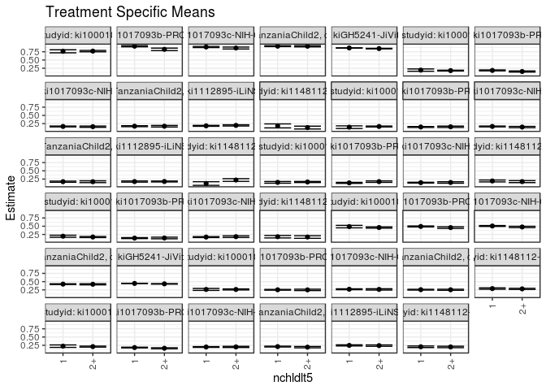

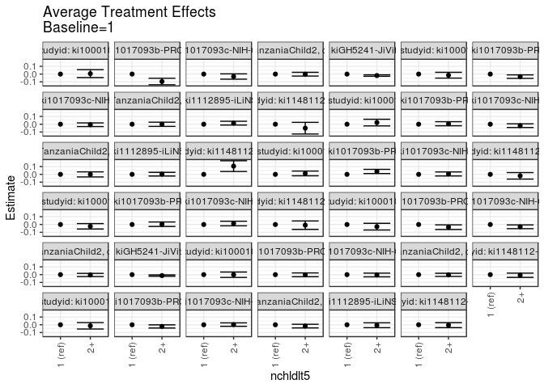

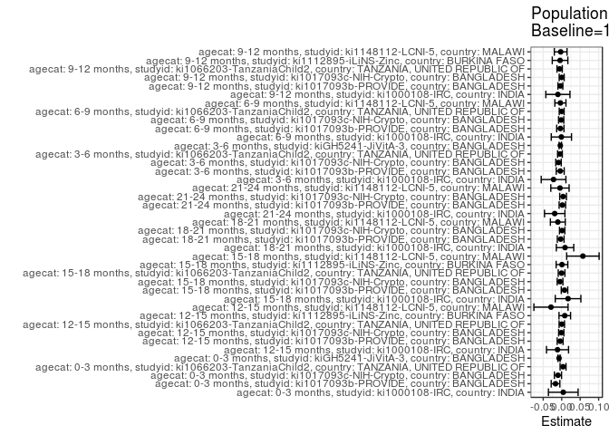

## Results Table

### Parameter: TSM

| agecat | studyid | country | intervention_level | baseline_level | estimate | ci_lower | ci_upper |
| --- | --- | --- | --- | --- | --- | --- | --- |
| 0-3 months | ki1000108-IRC | INDIA | 1 | NA | 0.7637238 | 0.7176819 | 0.8097657 |
| 0-3 months | ki1000108-IRC | INDIA | 2+ | NA | 0.7694802 | 0.7477344 | 0.7912261 |
| 0-3 months | ki1017093b-PROVIDE | BANGLADESH | 1 | NA | 0.9183476 | 0.8997839 | 0.9369113 |
| 0-3 months | ki1017093b-PROVIDE | BANGLADESH | 2+ | NA | 0.8229314 | 0.7854832 | 0.8603796 |
| 0-3 months | ki1017093c-NIH-Crypto | BANGLADESH | 1 | NA | 0.8946226 | 0.8769502 | 0.9122949 |
| 0-3 months | ki1017093c-NIH-Crypto | BANGLADESH | 2+ | NA | 0.8631488 | 0.8338654 | 0.8924322 |
| 0-3 months | ki1066203-TanzaniaChild2 | TANZANIA, UNITED REPUBLIC OF | 1 | NA | 0.9186900 | 0.9055135 | 0.9318665 |
| 0-3 months | ki1066203-TanzaniaChild2 | TANZANIA, UNITED REPUBLIC OF | 2+ | NA | 0.9173614 | 0.8973935 | 0.9373293 |
| 0-3 months | kiGH5241-JiVitA-3 | BANGLADESH | 1 | NA | 0.8648408 | 0.8605524 | 0.8691292 |
| 0-3 months | kiGH5241-JiVitA-3 | BANGLADESH | 2+ | NA | 0.8458968 | 0.8371285 | 0.8546651 |
| 3-6 months | ki1000108-IRC | INDIA | 1 | NA | 0.4880871 | 0.4500822 | 0.5260920 |
| 3-6 months | ki1000108-IRC | INDIA | 2+ | NA | 0.4602393 | 0.4405304 | 0.4799482 |
| 3-6 months | ki1017093b-PROVIDE | BANGLADESH | 1 | NA | 0.4930851 | 0.4782765 | 0.5078937 |
| 3-6 months | ki1017093b-PROVIDE | BANGLADESH | 2+ | NA | 0.4583940 | 0.4329732 | 0.4838148 |
| 3-6 months | ki1017093c-NIH-Crypto | BANGLADESH | 1 | NA | 0.5066892 | 0.4927701 | 0.5206083 |
| 3-6 months | ki1017093c-NIH-Crypto | BANGLADESH | 2+ | NA | 0.4770470 | 0.4569156 | 0.4971784 |
| 3-6 months | ki1066203-TanzaniaChild2 | TANZANIA, UNITED REPUBLIC OF | 1 | NA | 0.4242709 | 0.4132876 | 0.4352542 |
| 3-6 months | ki1066203-TanzaniaChild2 | TANZANIA, UNITED REPUBLIC OF | 2+ | NA | 0.4198754 | 0.4024693 | 0.4372816 |
| 3-6 months | kiGH5241-JiVitA-3 | BANGLADESH | 1 | NA | 0.4451374 | 0.4405893 | 0.4496855 |
| 3-6 months | kiGH5241-JiVitA-3 | BANGLADESH | 2+ | NA | 0.4325795 | 0.4243145 | 0.4408446 |
| 6-9 months | ki1000108-IRC | INDIA | 1 | NA | 0.2635013 | 0.2333894 | 0.2936132 |
| 6-9 months | ki1000108-IRC | INDIA | 2+ | NA | 0.2625137 | 0.2464953 | 0.2785321 |
| 6-9 months | ki1017093b-PROVIDE | BANGLADESH | 1 | NA | 0.2528300 | 0.2402901 | 0.2653699 |
| 6-9 months | ki1017093b-PROVIDE | BANGLADESH | 2+ | NA | 0.2503794 | 0.2293940 | 0.2713648 |
| 6-9 months | ki1017093c-NIH-Crypto | BANGLADESH | 1 | NA | 0.2688825 | 0.2558977 | 0.2818673 |
| 6-9 months | ki1017093c-NIH-Crypto | BANGLADESH | 2+ | NA | 0.2643525 | 0.2444167 | 0.2842882 |
| 6-9 months | ki1066203-TanzaniaChild2 | TANZANIA, UNITED REPUBLIC OF | 1 | NA | 0.2558603 | 0.2442018 | 0.2675187 |
| 6-9 months | ki1066203-TanzaniaChild2 | TANZANIA, UNITED REPUBLIC OF | 2+ | NA | 0.2531533 | 0.2368996 | 0.2694071 |
| 6-9 months | ki1148112-LCNI-5 | MALAWI | 1 | NA | 0.2888550 | 0.2679692 | 0.3097407 |
| 6-9 months | ki1148112-LCNI-5 | MALAWI | 2+ | NA | 0.2808990 | 0.2637858 | 0.2980122 |

[output cut: 52 more lines]

### Parameter: E(Y)

| agecat | studyid | country | intervention_level | baseline_level | estimate | ci_lower | ci_upper |
| --- | --- | --- | --- | --- | --- | --- | --- |
| 0-3 months | ki1000108-IRC | INDIA | NA | NA | 0.7679906 | 0.7485485 | 0.7874326 |
| 0-3 months | ki1017093b-PROVIDE | BANGLADESH | NA | NA | 0.9016472 | 0.8868914 | 0.9164029 |
| 0-3 months | ki1017093c-NIH-Crypto | BANGLADESH | NA | NA | 0.8845220 | 0.8699746 | 0.8990694 |
| 0-3 months | ki1066203-TanzaniaChild2 | TANZANIA, UNITED REPUBLIC OF | NA | NA | 0.9223779 | 0.9122086 | 0.9325472 |
| 0-3 months | kiGH5241-JiVitA-3 | BANGLADESH | NA | NA | 0.8576772 | 0.8546652 | 0.8606893 |
| 3-6 months | ki1000108-IRC | INDIA | NA | NA | 0.4660717 | 0.4485044 | 0.4836390 |
| 3-6 months | ki1017093b-PROVIDE | BANGLADESH | NA | NA | 0.4890611 | 0.4760060 | 0.5021163 |
| 3-6 months | ki1017093c-NIH-Crypto | BANGLADESH | NA | NA | 0.4980544 | 0.4869892 | 0.5091196 |
| 3-6 months | ki1066203-TanzaniaChild2 | TANZANIA, UNITED REPUBLIC OF | NA | NA | 0.4195871 | 0.4109053 | 0.4282689 |
| 3-6 months | kiGH5241-JiVitA-3 | BANGLADESH | NA | NA | 0.4414051 | 0.4384353 | 0.4443748 |
| 6-9 months | ki1000108-IRC | INDIA | NA | NA | 0.2626310 | 0.2487635 | 0.2764985 |
| 6-9 months | ki1017093b-PROVIDE | BANGLADESH | NA | NA | 0.2491653 | 0.2371134 | 0.2612172 |
| 6-9 months | ki1017093c-NIH-Crypto | BANGLADESH | NA | NA | 0.2675097 | 0.2569518 | 0.2780676 |
| 6-9 months | ki1066203-TanzaniaChild2 | TANZANIA, UNITED REPUBLIC OF | NA | NA | 0.2558522 | 0.2469636 | 0.2647409 |
| 6-9 months | ki1148112-LCNI-5 | MALAWI | NA | NA | 0.2853462 | 0.2727187 | 0.2979736 |
| 9-12 months | ki1000108-IRC | INDIA | NA | NA | 0.2132244 | 0.1989917 | 0.2274571 |
| 9-12 months | ki1017093b-PROVIDE | BANGLADESH | NA | NA | 0.1775316 | 0.1681968 | 0.1868664 |
| 9-12 months | ki1017093c-NIH-Crypto | BANGLADESH | NA | NA | 0.1978449 | 0.1874487 | 0.2082411 |
| 9-12 months | ki1066203-TanzaniaChild2 | TANZANIA, UNITED REPUBLIC OF | NA | NA | 0.2046179 | 0.1945139 | 0.2147219 |
| 9-12 months | ki1112895-iLiNS-Zinc | BURKINA FASO | NA | NA | 0.2420700 | 0.2289407 | 0.2551993 |
| 9-12 months | ki1148112-LCNI-5 | MALAWI | NA | NA | 0.2022567 | 0.1863082 | 0.2182053 |
| 12-15 months | ki1000108-IRC | INDIA | NA | NA | 0.1821426 | 0.1693469 | 0.1949383 |
| 12-15 months | ki1017093b-PROVIDE | BANGLADESH | NA | NA | 0.1800324 | 0.1683272 | 0.1917375 |
| 12-15 months | ki1017093c-NIH-Crypto | BANGLADESH | NA | NA | 0.1640603 | 0.1535198 | 0.1746008 |
| 12-15 months | ki1066203-TanzaniaChild2 | TANZANIA, UNITED REPUBLIC OF | NA | NA | 0.1737296 | 0.1623947 | 0.1850645 |
| 12-15 months | ki1112895-iLiNS-Zinc | BURKINA FASO | NA | NA | 0.1921946 | 0.1813846 | 0.2030045 |
| 12-15 months | ki1148112-LCNI-5 | MALAWI | NA | NA | 0.1530519 | 0.1191456 | 0.1869583 |
| 15-18 months | ki1000108-IRC | INDIA | NA | NA | 0.1604586 | 0.1468913 | 0.1740260 |
| 15-18 months | ki1017093b-PROVIDE | BANGLADESH | NA | NA | 0.1563514 | 0.1445823 | 0.1681205 |
| 15-18 months | ki1017093c-NIH-Crypto | BANGLADESH | NA | NA | 0.1611973 | 0.1506617 | 0.1717329 |
| 15-18 months | ki1066203-TanzaniaChild2 | TANZANIA, UNITED REPUBLIC OF | NA | NA | 0.1702121 | 0.1559390 | 0.1844852 |
| 15-18 months | ki1112895-iLiNS-Zinc | BURKINA FASO | NA | NA | 0.1750401 | 0.1647066 | 0.1853735 |
| 15-18 months | ki1148112-LCNI-5 | MALAWI | NA | NA | 0.1724751 | 0.1407874 | 0.2041628 |
| 18-21 months | ki1000108-IRC | INDIA | NA | NA | 0.1589791 | 0.1455977 | 0.1723606 |
| 18-21 months | ki1017093b-PROVIDE | BANGLADESH | NA | NA | 0.1324882 | 0.1210438 | 0.1439326 |
| 18-21 months | ki1017093c-NIH-Crypto | BANGLADESH | NA | NA | 0.1426609 | 0.1319333 | 0.1533885 |
| 18-21 months | ki1148112-LCNI-5 | MALAWI | NA | NA | 0.1816953 | 0.1614502 | 0.2019405 |
| 21-24 months | ki1000108-IRC | INDIA | NA | NA | 0.1777340 | 0.1639174 | 0.1915507 |
| 21-24 months | ki1017093b-PROVIDE | BANGLADESH | NA | NA | 0.1419705 | 0.1305335 | 0.1534075 |
| 21-24 months | ki1017093c-NIH-Crypto | BANGLADESH | NA | NA | 0.1750500 | 0.1624914 | 0.1876087 |
| 21-24 months | ki1148112-LCNI-5 | MALAWI | NA | NA | 0.1772328 | 0.1503917 | 0.2040738 |

### Parameter: ATE

| agecat | studyid | country | intervention_level | baseline_level | estimate | ci_lower | ci_upper |
| --- | --- | --- | --- | --- | --- | --- | --- |
| 0-3 months | ki1000108-IRC | INDIA | 1 | 1 | 0.0000000 | 0.0000000 | 0.0000000 |
| 0-3 months | ki1000108-IRC | INDIA | 2+ | 1 | 0.0057564 | -0.0452344 | 0.0567473 |
| 0-3 months | ki1017093b-PROVIDE | BANGLADESH | 1 | 1 | 0.0000000 | 0.0000000 | 0.0000000 |
| 0-3 months | ki1017093b-PROVIDE | BANGLADESH | 2+ | 1 | -0.0954162 | -0.1370634 | -0.0537690 |
| 0-3 months | ki1017093c-NIH-Crypto | BANGLADESH | 1 | 1 | 0.0000000 | 0.0000000 | 0.0000000 |
| 0-3 months | ki1017093c-NIH-Crypto | BANGLADESH | 2+ | 1 | -0.0314738 | -0.0659174 | 0.0029699 |
| 0-3 months | ki1066203-TanzaniaChild2 | TANZANIA, UNITED REPUBLIC OF | 1 | 1 | 0.0000000 | 0.0000000 | 0.0000000 |
| 0-3 months | ki1066203-TanzaniaChild2 | TANZANIA, UNITED REPUBLIC OF | 2+ | 1 | -0.0013286 | -0.0252992 | 0.0226419 |
| 0-3 months | kiGH5241-JiVitA-3 | BANGLADESH | 1 | 1 | 0.0000000 | 0.0000000 | 0.0000000 |
| 0-3 months | kiGH5241-JiVitA-3 | BANGLADESH | 2+ | 1 | -0.0189439 | -0.0284633 | -0.0094246 |
| 3-6 months | ki1000108-IRC | INDIA | 1 | 1 | 0.0000000 | 0.0000000 | 0.0000000 |
| 3-6 months | ki1000108-IRC | INDIA | 2+ | 1 | -0.0278478 | -0.0708295 | 0.0151340 |
| 3-6 months | ki1017093b-PROVIDE | BANGLADESH | 1 | 1 | 0.0000000 | 0.0000000 | 0.0000000 |
| 3-6 months | ki1017093b-PROVIDE | BANGLADESH | 2+ | 1 | -0.0346911 | -0.0646143 | -0.0047679 |
| 3-6 months | ki1017093c-NIH-Crypto | BANGLADESH | 1 | 1 | 0.0000000 | 0.0000000 | 0.0000000 |
| 3-6 months | ki1017093c-NIH-Crypto | BANGLADESH | 2+ | 1 | -0.0296422 | -0.0540536 | -0.0052309 |
| 3-6 months | ki1066203-TanzaniaChild2 | TANZANIA, UNITED REPUBLIC OF | 1 | 1 | 0.0000000 | 0.0000000 | 0.0000000 |
| 3-6 months | ki1066203-TanzaniaChild2 | TANZANIA, UNITED REPUBLIC OF | 2+ | 1 | -0.0043955 | -0.0249904 | 0.0161994 |
| 3-6 months | kiGH5241-JiVitA-3 | BANGLADESH | 1 | 1 | 0.0000000 | 0.0000000 | 0.0000000 |
| 3-6 months | kiGH5241-JiVitA-3 | BANGLADESH | 2+ | 1 | -0.0125579 | -0.0217323 | -0.0033834 |
| 6-9 months | ki1000108-IRC | INDIA | 1 | 1 | 0.0000000 | 0.0000000 | 0.0000000 |
| 6-9 months | ki1000108-IRC | INDIA | 2+ | 1 | -0.0009876 | -0.0352902 | 0.0333150 |
| 6-9 months | ki1017093b-PROVIDE | BANGLADESH | 1 | 1 | 0.0000000 | 0.0000000 | 0.0000000 |
| 6-9 months | ki1017093b-PROVIDE | BANGLADESH | 2+ | 1 | -0.0024506 | -0.0267980 | 0.0218968 |
| 6-9 months | ki1017093c-NIH-Crypto | BANGLADESH | 1 | 1 | 0.0000000 | 0.0000000 | 0.0000000 |
| 6-9 months | ki1017093c-NIH-Crypto | BANGLADESH | 2+ | 1 | -0.0045300 | -0.0282473 | 0.0191873 |
| 6-9 months | ki1066203-TanzaniaChild2 | TANZANIA, UNITED REPUBLIC OF | 1 | 1 | 0.0000000 | 0.0000000 | 0.0000000 |
| 6-9 months | ki1066203-TanzaniaChild2 | TANZANIA, UNITED REPUBLIC OF | 2+ | 1 | -0.0027070 | -0.0228559 | 0.0174420 |
| 6-9 months | ki1148112-LCNI-5 | MALAWI | 1 | 1 | 0.0000000 | 0.0000000 | 0.0000000 |
| 6-9 months | ki1148112-LCNI-5 | MALAWI | 2+ | 1 | -0.0079559 | -0.0351085 | 0.0191967 |

[output cut: 52 more lines]

### Parameter: PAR

| agecat | studyid | country | intervention_level | baseline_level | estimate | ci_lower | ci_upper |
| --- | --- | --- | --- | --- | --- | --- | --- |
| 0-3 months | ki1000108-IRC | INDIA | 1 | NA | 0.0042668 | -0.0358841 | 0.0444177 |
| 0-3 months | ki1017093b-PROVIDE | BANGLADESH | 1 | NA | -0.0167004 | -0.0284015 | -0.0049993 |
| 0-3 months | ki1017093c-NIH-Crypto | BANGLADESH | 1 | NA | -0.0101006 | -0.0197655 | -0.0004357 |
| 0-3 months | ki1066203-TanzaniaChild2 | TANZANIA, UNITED REPUBLIC OF | 1 | NA | 0.0036879 | -0.0043050 | 0.0116807 |
| 0-3 months | kiGH5241-JiVitA-3 | BANGLADESH | 1 | NA | -0.0071635 | -0.0100826 | -0.0042445 |
| 3-6 months | ki1000108-IRC | INDIA | 1 | NA | -0.0220154 | -0.0554301 | 0.0113993 |
| 3-6 months | ki1017093b-PROVIDE | BANGLADESH | 1 | NA | -0.0040240 | -0.0147999 | 0.0067519 |
| 3-6 months | ki1017093c-NIH-Crypto | BANGLADESH | 1 | NA | -0.0086348 | -0.0160440 | -0.0012257 |
| 3-6 months | ki1066203-TanzaniaChild2 | TANZANIA, UNITED REPUBLIC OF | 1 | NA | -0.0046838 | -0.0110687 | 0.0017012 |
| 3-6 months | kiGH5241-JiVitA-3 | BANGLADESH | 1 | NA | -0.0037323 | -0.0069820 | -0.0004827 |
| 6-9 months | ki1000108-IRC | INDIA | 1 | NA | -0.0008703 | -0.0282877 | 0.0265472 |
| 6-9 months | ki1017093b-PROVIDE | BANGLADESH | 1 | NA | -0.0036647 | -0.0135268 | 0.0061974 |
| 6-9 months | ki1017093c-NIH-Crypto | BANGLADESH | 1 | NA | -0.0013728 | -0.0084294 | 0.0056838 |
| 6-9 months | ki1066203-TanzaniaChild2 | TANZANIA, UNITED REPUBLIC OF | 1 | NA | -0.0000080 | -0.0066138 | 0.0065977 |
| 6-9 months | ki1148112-LCNI-5 | MALAWI | 1 | NA | -0.0035088 | -0.0185246 | 0.0115071 |
| 9-12 months | ki1000108-IRC | INDIA | 1 | NA | -0.0102628 | -0.0428939 | 0.0223683 |
| 9-12 months | ki1017093b-PROVIDE | BANGLADESH | 1 | NA | -0.0035422 | -0.0101965 | 0.0031122 |
| 9-12 months | ki1017093c-NIH-Crypto | BANGLADESH | 1 | NA | 0.0000123 | -0.0067180 | 0.0067425 |
| 9-12 months | ki1066203-TanzaniaChild2 | TANZANIA, UNITED REPUBLIC OF | 1 | NA | -0.0055014 | -0.0126889 | 0.0016862 |
| 9-12 months | ki1112895-iLiNS-Zinc | BURKINA FASO | 1 | NA | -0.0044233 | -0.0255476 | 0.0167009 |
| 9-12 months | ki1148112-LCNI-5 | MALAWI | 1 | NA | -0.0027507 | -0.0199439 | 0.0144424 |
| 12-15 months | ki1000108-IRC | INDIA | 1 | NA | -0.0112689 | -0.0411047 | 0.0185669 |
| 12-15 months | ki1017093b-PROVIDE | BANGLADESH | 1 | NA | -0.0042226 | -0.0122015 | 0.0037563 |
| 12-15 months | ki1017093c-NIH-Crypto | BANGLADESH | 1 | NA | -0.0011712 | -0.0082322 | 0.0058898 |
| 12-15 months | ki1066203-TanzaniaChild2 | TANZANIA, UNITED REPUBLIC OF | 1 | NA | 0.0003401 | -0.0069729 | 0.0076532 |
| 12-15 months | ki1112895-iLiNS-Zinc | BURKINA FASO | 1 | NA | 0.0083805 | -0.0072719 | 0.0240330 |
| 12-15 months | ki1148112-LCNI-5 | MALAWI | 1 | NA | -0.0289815 | -0.0752165 | 0.0172536 |
| 15-18 months | ki1000108-IRC | INDIA | 1 | NA | 0.0172382 | -0.0174651 | 0.0519416 |
| 15-18 months | ki1017093b-PROVIDE | BANGLADESH | 1 | NA | 0.0076284 | -0.0011489 | 0.0164056 |
| 15-18 months | ki1017093c-NIH-Crypto | BANGLADESH | 1 | NA | -0.0044341 | -0.0121483 | 0.0032801 |
| 15-18 months | ki1066203-TanzaniaChild2 | TANZANIA, UNITED REPUBLIC OF | 1 | NA | -0.0003138 | -0.0093133 | 0.0086858 |
| 15-18 months | ki1112895-iLiNS-Zinc | BURKINA FASO | 1 | NA | 0.0007649 | -0.0150083 | 0.0165381 |
| 15-18 months | ki1148112-LCNI-5 | MALAWI | 1 | NA | 0.0573967 | 0.0134822 | 0.1013112 |
| 18-21 months | ki1000108-IRC | INDIA | 1 | NA | 0.0090730 | -0.0144997 | 0.0326457 |
| 18-21 months | ki1017093b-PROVIDE | BANGLADESH | 1 | NA | -0.0026938 | -0.0118071 | 0.0064195 |
| 18-21 months | ki1017093c-NIH-Crypto | BANGLADESH | 1 | NA | 0.0012728 | -0.0059713 | 0.0085169 |
| 18-21 months | ki1148112-LCNI-5 | MALAWI | 1 | NA | -0.0104804 | -0.0305842 | 0.0096234 |
| 21-24 months | ki1000108-IRC | INDIA | 1 | NA | -0.0189001 | -0.0465102 | 0.0087101 |
| 21-24 months | ki1017093b-PROVIDE | BANGLADESH | 1 | NA | 0.0018322 | -0.0069222 | 0.0105865 |
| 21-24 months | ki1017093c-NIH-Crypto | BANGLADESH | 1 | NA | 0.0037773 | -0.0052893 | 0.0128439 |
| 21-24 months | ki1148112-LCNI-5 | MALAWI | 1 | NA | -0.0046907 | -0.0294468 | 0.0200653 |